# Muestro

CURSO R

10 de marzo de 2020

# Distribución Muestral

```r
library(tseries)
```

El siguiente ejemplo permitirá entender de forma rpáctica el concepto de distribución muestral.

**Distribución Rectangular**

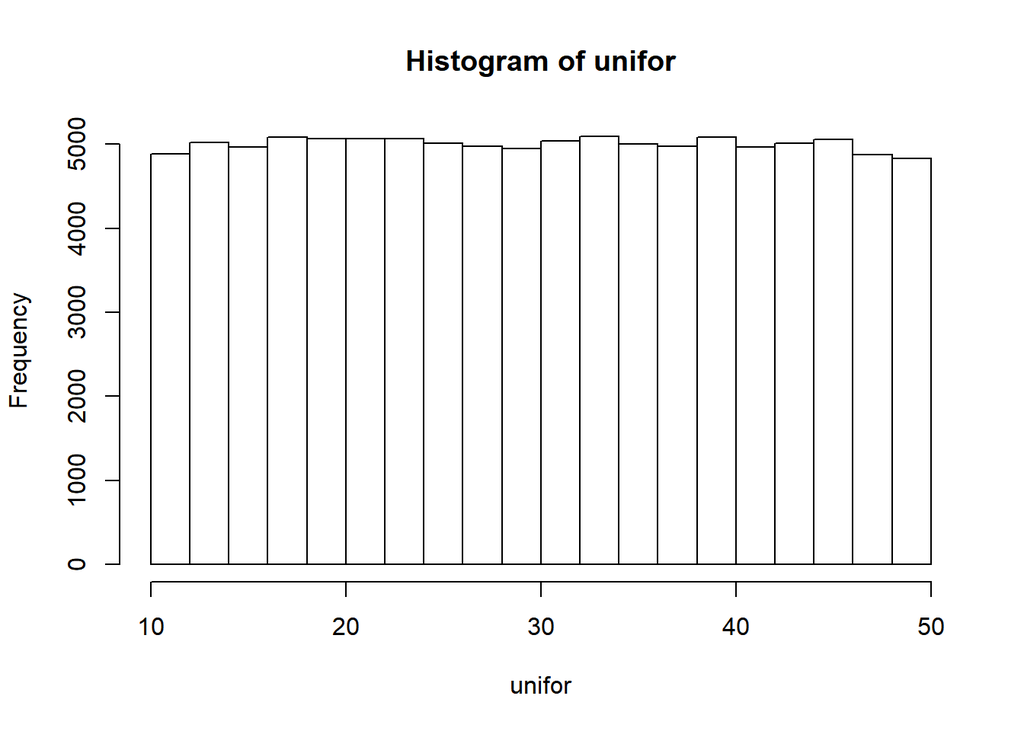

```r
unifor<-runif(100000,10,50)
#plot(unifor)
hist(unifor)
```

```r
munif<-mean(unifor)
sdunif<-sd(unifor)
```

Con media $\mu=$ 29.9567743 y desviaciín estándar $\sigma=$ 11.5070641

*Fórmula de la media y varianza para V.A. discretas*

$$\mu=\frac{\sum_{i=1}^nx_i}{N}$$

$$\sigma^2=\frac{\sum_{i=1}^n(x_i-\mu)^2}{N}$$

**Distribución Muestral**

Al tomar tamaños de muestra $n=30$ se tiene

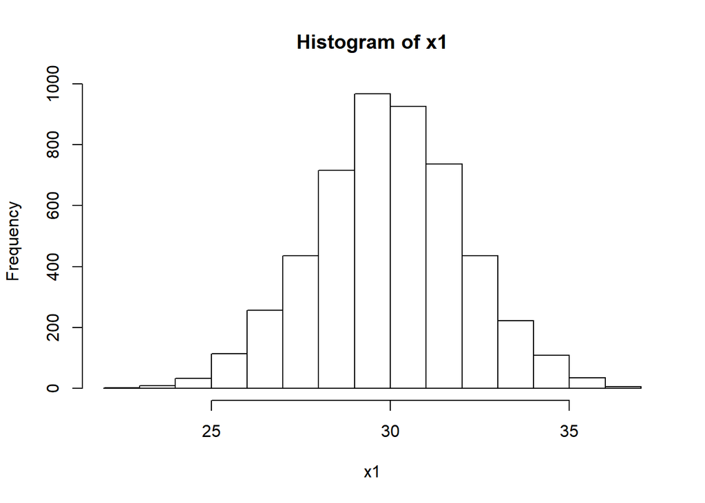

```r
x1<-rep(NA, 5000)

n<-30
for (i in 1:5000){
x1[i]<-mean(sample(unifor, n, replace=FALSE))
}

hist(x1)
```

```r
st1<-shapiro.test(x1)
jbt1<-jarque.bera.test(x1)
```

**Se hace prueba para la normalidad**

$H_0:$ La V.A. se distribuye de forma normal

$H_A:$ La V.A. no se dist. de forma normal

Como el valor $p=$ 0.1133538 que es mayor a $\alpha=.05$ no existe suficiente evidencia para rechazar $H_0$ por lo tanto podemos asumir normalidad de la medias de las muestras.

**La conclusión de este ejemplo empírico, es que no importa de que dsitribución provengan las muestras, las medias de las muestras se comportarán como una distribucíón normal a medida que el tamaño de la muestar aumenta**

```r
jarque.bera.test(unifor)
```

```
##
##  Jarque Bera Test
##
## data:  unifor
## X-squared = 5971.9, df = 2, p-value < 2.2e-16
```

Lo que nos indica que no se comporta como una V.A. con distribución normal.

**¿Cuál es el valor de la media de las medias?**

```r
mean(x1)
```

```
## [1] 29.97184
```

Se observa que aunque no es igual al valor de la media poblacional de la distribución rectacngular 29.9567743, es muy cercana, de hecho y de haber encontrado todas las combinaciones de N tomadas n a la vez el valor sería identico. Lo que significa que:

$$\bar{\bar{X}}=\mu$$
#Estimación Puntual

Si seleccionamos a una de las X1 que generamos, a cualquiera de ellas, sería un estimador punual $\mu$. Por ejemplo:

```r
x1[sample(1:5000, 1)]
```

```
## [1] 30.05134
```

Si alguien hiciera el estudio y tomara otra muestra de 3o elementos podría obtener

```r
x1[sample(1:5000, 1)]
```

```
## [1] 29.15257
```

**¿A quién le cree usted, suponiendo que no conoce los parámetros poblacionales?**

Pues a todos y a ninguno, ya que fueron sacados de una distribución muestral de tamaño 30 pero la probabilidad de que sean igual al parámetro poblacional es casi seguramente cero.

# Intervalos de confianza

Si tomamos nuevemante una muestra de 30 elementos y calculamos su media, pero a diferencia de la estimación puentual a esta le colocamos un Límite Inferior y un Límite Superior con una probabiidad de que el parámetro real pero desconocido se encuentre en dichi untervalo.

$$LI=\bar{x}-z_{\alpha/2}\sigma_{\bar{x}}$$

$$LI=\bar{x}+z_{\alpha/2}\sigma_{\bar{x}}$$

Se hace conveiente explicar el concepto de error estándar $\sigma_{\bar{x}}$. El error estándar es el equivalente a la desviación estándar pero este es un parámetro de la medida de disperción de las distribuciones muestrales, la cual también sepuede obtener de la siguiente manera:

$$\sigma_{\bar{x}}=\frac{\sigma}{\sqrt{n}}$$

El dilema al que nos enfrentamos ahora es que para tener el interval de confinza se emplea $\sigma$ quien es un parámetro poblacional, por lo que es necesario encontrar un estimador de $\sigma^2$

$$\hat{\sigma}^2=s^2$$

Un estimador de $\sigma^2_{\bar{x}}$ es $S^2_{\bar{x}}$. Por la tanto

$$S^2_{\bar{x}}=\frac{S^2}{n}$$

Para nuestro caso

```r
xm<-sample(unifor, 30, replace=FALSE)
xp<-mean(xm)
s<-sd(xm)
sx<-s/n^.5
z<-qnorm(0.975)

LI<-xp-z*sx
LS<-xp+z*sx
LI
```

```
## [1] 22.89379
```

```r
LS
```

```
## [1] 31.49507
```

```r
munif
```

```
## [1] 29.95677
```

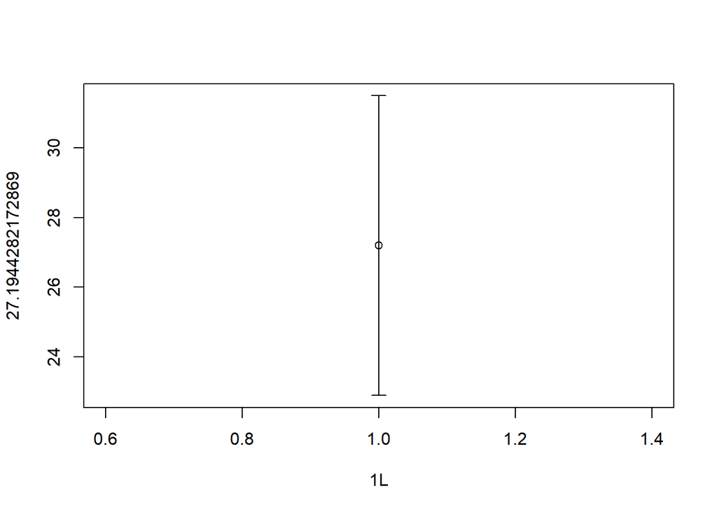

```r
require(plotrix)
plotCI(xp, ui=LS, li=LI)
```

Con lo que se aprecia que la media poblacional está contenida en el intervalo de confianza.

Hagamos el experimento con diez muestras de tamaño 30.

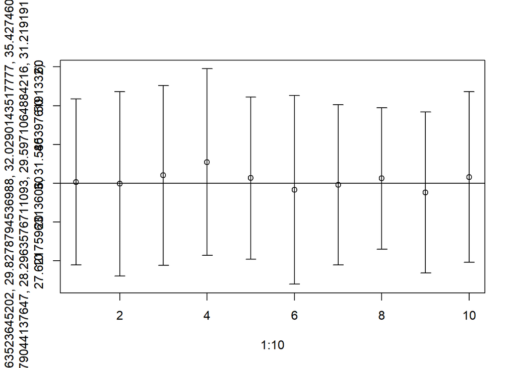

```r
mi<-rep(NA, times=10*30)
dim(mi)<-c(10, 30)

for (i in 1:10){
  mi[i,]<-sample(unifor,30, replace=FALSE)
}

mmi<-apply(mi, 1, mean)
sdmi<-apply(mi, 1, sd)

LIi<-mmi-z*sdmi
LSi<-mmi+z*sdmi

plotCI(mmi, ui=LSi, li=LIi)
abline(h=munif)
```

# Muestreo

La fórmula que comunmente se emplea para el muestreo es

$$n=\frac{\sigma^2N}{(N-1)D^2+\sigma^2}$$

$$D=\frac{B}{z_{\alpha/2}}$$

Donde:

- B = Error de Muestreo
- $z_{\alpha/2}$ = Nivel de significancia
- $\sigma^2$ = Varianza poblacional
- n = Tamaño de la población

Sin embargo, se deberá estimar a $\sigma^2$ com $S^2$. p Por lo que:

$$n=\frac{S^2N}{(N-1)D^2+S^2}$$

Ejemplo:

Para nuestro caso de la distribución rectangular, suponga que deseamos un error de $\pm1$ un nivel de significancia $\alpha=.05$, el tamaño de la población es N=10,000 elementos y un muestreo piloto con 30 elementos arrojo una varianza mestral de 120.23. Calcule el tamaño de la muestra.

```r
s2<-120.23
N<-10000
B=1
D=B/z

n<-s2*N/((N-1)*D^2+s2)
ceiling(n)
```

```
## [1] 442
```

¿Qué pasa si se duplica al error, B=2?

```r
s2<-120.23
N<-10000
B=2
D=B/z

n<-s2*N/((N-1)*D^2+s2)
ceiling(n)
```

```
## [1] 115
```

¿Qué pasa si se reduce el error de B=1 a B=0.5?

```r
s2<-120.23
N<-10000
B=.5
D=B/z

n<-s2*N/((N-1)*D^2+s2)
ceiling(n)
```

```
## [1] 1560
```

¿Qué pasa si el nivel de significancia pasa de .05 a .01?

```r
s2<-120.23
N<-10000
B=2
za<-qnorm(.995)
D=B/za

n<-s2*N/((N-1)*D^2+s2)
ceiling(n)
```

```
## [1] 196
```

¿Qué pasa si el nivel de significancia pasa de .05 a .1?

```r
s2<-120.23
N<-10000
B=2
za<-qnorm(.95)
D=B/za

n<-s2*N/((N-1)*D^2+s2)
ceiling(n)
```

```
## [1] 81
```

Es más sensible el tamaño de la muestra al error que al nivel de significancia $\alpha$.